# hw3-5.1

Mark Pearl

9/11/2019

```r
uscrime_data <- read.table('C:/Users/mjpearl/Desktop/omsa/ISYE_6501/hw3/data/uscrime.txt',header = TRUE, stringsAsFactors = FALSE)
head(uscrime_data)
```

```
##      M So   Ed  Po1  Po2    LF   M.F Pop   NW    U1  U2 Wealth Ineq
## 1 15.1  1  9.1  5.8  5.6 0.510  95.0  33 30.1 0.108 4.1   3940 26.1
## 2 14.3  0 11.3 10.3  9.5 0.583 101.2  13 10.2 0.096 3.6   5570 19.4
## 3 14.2  1  8.9  4.5  4.4 0.533  96.9  18 21.9 0.094 3.3   3180 25.0
## 4 13.6  0 12.1 14.9 14.1 0.577  99.4 157  8.0 0.102 3.9   6730 16.7
## 5 14.1  0 12.1 10.9 10.1 0.591  98.5  18  3.0 0.091 2.0   5780 17.4
## 6 12.1  0 11.0 11.8 11.5 0.547  96.4  25  4.4 0.084 2.9   6890 12.6
##       Prob    Time Crime
## 1 0.084602 26.2011   791
## 2 0.029599 25.2999  1635
## 3 0.083401 24.3006   578
## 4 0.015801 29.9012  1969
## 5 0.041399 21.2998  1234
## 6 0.034201 20.9995   682
```

## Plots Section

The following plots will conduct exploratory analysis on the data to get a sense of the data’s distribution and to see if we can spot any outliers with a visual representation.

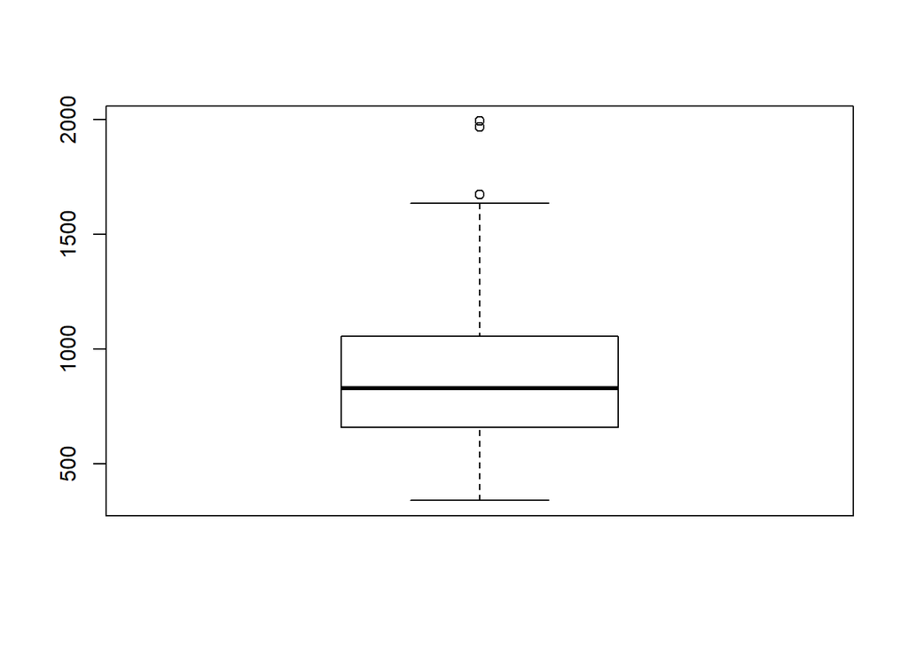

```r
boxplot(x= uscrime_data$Crime)
```

From the boxplot we can see that there are a few observations above the whisker which indicates values past Q3 are outliers (2 observations closest to a Crime value of 2000). There does not seem to be any observations in the lower quartiles that indicate any outliers.

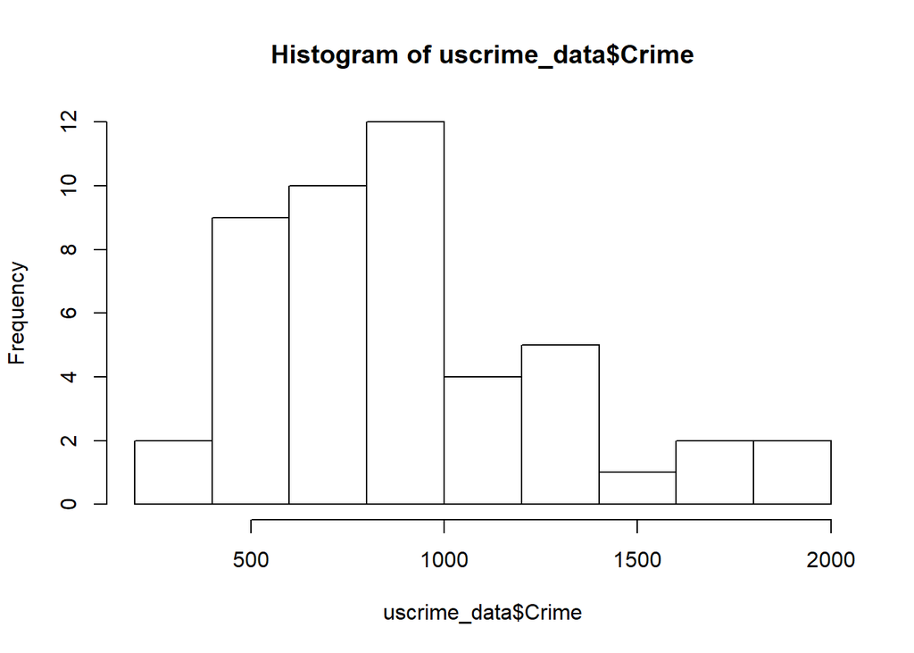

```r
hist(uscrime_data$Crime)
```

The result of histogram indicates a skewed distribution for the right tail. For a grubbs test to be effective it is implied that the data follows a normal distribution. However our data does follow a normal distribution towards the middle portion of the graph, so it could mean that we have outlying data. We will continue with conducting the grubbs test for further investigation.

## Grub Test Section

To ensure we test observations represented by the minimum and maximum values on the graph, we will use the “opposite” parameter of the grubbs test function.

```r
grubbs.test(x=uscrime_data$Crime, type = 10, opposite = F)
```

```
##
##  Grubbs test for one outlier
##
## data:  uscrime_data$Crime
## G = 2.81287, U = 0.82426, p-value = 0.07887
## alternative hypothesis: highest value 1993 is an outlier
```

```r
grubbs.test(x=uscrime_data$Crime, type = 10, opposite = T)
```

```
##
##  Grubbs test for one outlier
##
## data:  uscrime_data$Crime
## G = 1.45589, U = 0.95292, p-value = 1
## alternative hypothesis: lowest value 342 is an outlier
```

The second output indicates that the lowest value of the crime feature is with a high certainty not an outlier as we retrieved a p-value of 1.